# MLM Logistic Regression

Erin M. Buchanan

9/3/2019

```r
knitr::opts_chunk$set(echo = TRUE)
library(ggplot2)
library(dplyr)
library(RCurl)
library(lme4)
##graph clean up code
cleanup = theme(panel.grid.major = element_blank(),
              panel.grid.minor = element_blank(),
              panel.background = element_blank(),
              axis.line = element_line(colour = "black"),
              legend.key = element_rect(fill = "white"),
              text = element_text(size = 15))
```

# About the Video

- This video covers multilevel logistic regression, assuming you understand a few things:
  - You know a little bit about logistic regression.
  - You know a little bit about multilevel models.
  - You know a good bit about R.

# About the Video

- If those aren’t true, try checking out:
  - MLM Videos: I have a few lectures, workshop, and examples: https://www.youtube.com/channel/UCMdihazndR0f9XBoSXWqnYg/search?view_as=subscriber&query=multilevel
  - Logistic Videos: Lectures and examples: https://www.youtube.com/channel/UCMdihazndR0f9XBoSXWqnYg/search?view_as=subscriber&query=logistic
  - Learn R: See week 1 software overview: http://statstools.com/learn/advanced-statistics/

# About the Data

- We are going to use data from a project that’s currently under review about reporting rates of outliers.
- You can find it and the preprint linked to our Open Science page: https://osf.io/52mqw/.

# Load the Data

```r
data_url <- getURL("https://raw.githubusercontent.com/doomlab/Outliers/master/paper/outliers%20complete.csv")
master <- read.csv(text = data_url)
names(master)
```

```
##  [1] "Reference.Code"
##  [2] "year"
##  [3] "time.pulled"
##  [4] "Type"
##  [5] "Journal"
##  [6] "authors"
##  [7] "article"
##  [8] "type.of.analysis"
##  [9] "original.sample.size"
## [10] "mention.outliers"
## [11] "peopleor.data.points"
## [12] "take.out.or.leave.in"
## [13] "run.with.or.without"
## [14] "outlier.description"
## [15] "reason.code"
## [16] "final.sample.size"
## [17] "number.outliers"
## [18] "difference.between.analyses.with.and.without"
## [19] "report.results.on.if.did.both"
## [20] "Basics"
## [21] "ANOVA"
## [22] "Regression"
## [23] "ChiSquare"
## [24] "Nonparametric"
## [25] "Modeling"
## [26] "BayesOther"
## [27] "Double.Checked"
```

# General Steps

- Data screening
  - Accuracy
  - Missing
  - Outliers*
  - Assumptions:
    - Independence
    - Multicollinearity
    - DV Ratios

# Data Screening

- Accuracy + missing data
- Outliers?

```r
##clean up the mention column
master$mention.outliers = factor(master$mention.outliers,
                      levels = c("no", "yes"),
                      labels = c("No", "Yes"))

summary(master$mention.outliers)
```

```
##   No  Yes
## 1778  457
```

# Assumptions

- Multicollinearity
- DV Ratios

```r
summary(master$mention.outliers)
```

```
##   No  Yes
## 1778  457
```

```r
table(master$Type, master$mention.outliers)
```

```
##
##                  No Yes
##   Clinical       93  11
##   Cognitive     181 118
##   Counseling     89  24
##   Developmental  96  35
##   Educational   102  12
##   Environmental 102  14
##   Forensics     117  15
##   IO            199  29
##   Methods       111  16
##   Neuro          87  28
##   Overview      196  50
##   Social        301  94
##   Sports        104  11
```

```r
table(master$time.pulled, master$mention.outliers)
```

```
##
##         No Yes
##   2012 915 170
##   2017 863 287
```

# Assumptions

- Independence: in this dataset we have both `Journal` and `Article` as structured variables.
- We can control for the non-independence by using a multilevel model.

# Visualize the Data

```r
##create a data frame of the percentages by time and type
outsummary = table(master$mention.outliers, master$time.pulled, master$Type)
outsummary = as.data.frame(outsummary)
colnames(outsummary) = c("mention.outliers", "time.pulled", "Type", "Freq")

outpercent = as.data.frame(group_by(outsummary, time.pulled, Type) %>%
  mutate(percent = Freq/sum(Freq)*100))

outpercent
```

```
##    mention.outliers time.pulled          Type Freq   percent
## 1                No        2012      Clinical   49 90.740741
## 2               Yes        2012      Clinical    5  9.259259
## 3                No        2017      Clinical   44 88.000000
## 4               Yes        2017      Clinical    6 12.000000
## 5                No        2012     Cognitive  113 68.902439
## 6               Yes        2012     Cognitive   51 31.097561
## 7                No        2017     Cognitive   68 50.370370
## 8               Yes        2017     Cognitive   67 49.629630
## 9                No        2012    Counseling   48 85.714286
## 10              Yes        2012    Counseling    8 14.285714
## 11               No        2017    Counseling   41 71.929825
## 12              Yes        2017    Counseling   16 28.070175
## 13               No        2012 Developmental   56 80.000000
## 14              Yes        2012 Developmental   14 20.000000
```

[output cut: 38 more lines]

# Visualize the Data

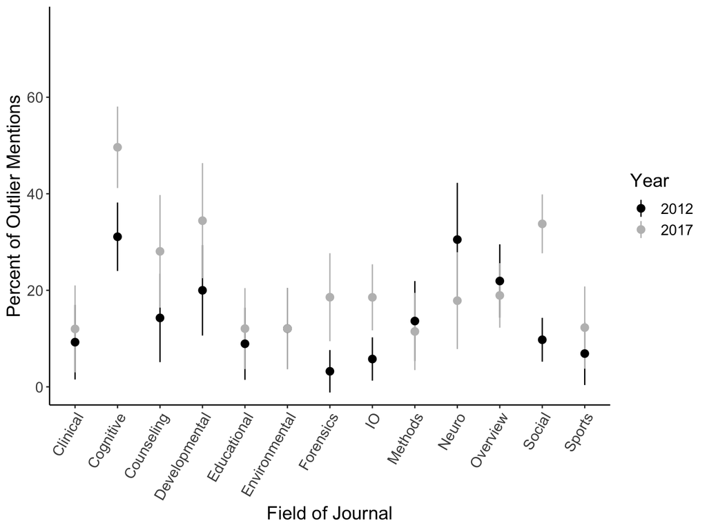

```r
#look at just outliers
graphdata = subset(outpercent, mention.outliers == "Yes")

#calculate CIs to add to graph
graphdata$sample = as.data.frame(table(master$time.pulled, master$Type))$Freq
graphdata$SE = sqrt(graphdata$percent*(100-graphdata$percent)/graphdata$sample)

#make the ggplot
dotplot = ggplot(graphdata, aes(Type, percent, color = time.pulled))
dotplot = dotplot +
  geom_pointrange(aes(ymin=percent-1.96*SE, ymax=percent+1.96*SE)) +
  xlab("Field of Journal") +
  ylab("Percent of Outlier Mentions") +
  theme(axis.text.x = element_text(angle = 60, hjust = 1)) +
  scale_color_manual(name = "Year",
                     values = c("black", "gray")) +
  coord_cartesian(ylim = c(0,75)) +
  cleanup

dotplot
```

# MLM Step 1

- A completely null model, no effects or random effects

```r
m1 <- glm(mention.outliers ~ 1,
          family = binomial(link="logit"),
          data = master)

summary(m1)
```

```
##
## Call:
## glm(formula = mention.outliers ~ 1, family = binomial(link = "logit"),
##     data = master)
##
## Deviance Residuals:
##     Min       1Q   Median       3Q      Max
## -0.6764  -0.6764  -0.6764  -0.6764   1.7817
##
## Coefficients:
##             Estimate Std. Error z value Pr(>|z|)
## (Intercept) -1.35856    0.05245   -25.9   <2e-16 ***
## ---
## Signif. codes:  0 '***' 0.001 '**' 0.01 '*' 0.05 '.' 0.1 ' ' 1
##
## (Dispersion parameter for binomial family taken to be 1)
##
##     Null deviance: 2264.2  on 2234  degrees of freedom
## Residual deviance: 2264.2  on 2234  degrees of freedom
## AIC: 2266.2
##
## Number of Fisher Scoring iterations: 4
```

# MLM Step 2

- Switch to `glmer`, add random intercept(s)

```r
m2 <- glmer(mention.outliers ~ 1 + (1 | Journal),
            data = master,
            family = binomial(link="logit"),
            control = glmerControl(optimizer = "bobyqa"),
            nAGQ = 0)

summary(m2)
```

```
## Generalized linear mixed model fit by maximum likelihood (Adaptive
##   Gauss-Hermite Quadrature, nAGQ = 0) [glmerMod]
##  Family: binomial  ( logit )
## Formula: mention.outliers ~ 1 + (1 | Journal)
##    Data: master
## Control: glmerControl(optimizer = "bobyqa")
##
##      AIC      BIC   logLik deviance df.resid
##   2159.9   2171.3  -1077.9   2155.9     2233
##
## Scaled residuals:
##     Min      1Q  Median      3Q     Max
## -0.8681 -0.4932 -0.4196 -0.2992  3.8039
##
## Random effects:
##  Groups  Name        Variance Std.Dev.
##  Journal (Intercept) 0.472    0.687
## Number of obs: 2235, groups:  Journal, 27
##
## Fixed effects:
##             Estimate Std. Error z value Pr(>|z|)
## (Intercept)  -1.6186     0.1477  -10.96   <2e-16 ***
## ---
## Signif. codes:  0 '***' 0.001 '**' 0.01 '*' 0.05 '.' 0.1 ' ' 1
```

# MLM Step 2.1

- Add a second random intercept

```r
m2.1 <- glmer(mention.outliers ~ 1 + (1 | Journal) + (1 | article),
            data = master,
            family = binomial(link="logit"),
            control = glmerControl(optimizer = "bobyqa"),
            nAGQ = 0)

summary(m2.1)
```

```
## Generalized linear mixed model fit by maximum likelihood (Adaptive
##   Gauss-Hermite Quadrature, nAGQ = 0) [glmerMod]
##  Family: binomial  ( logit )
## Formula: mention.outliers ~ 1 + (1 | Journal) + (1 | article)
##    Data: master
## Control: glmerControl(optimizer = "bobyqa")
##
##      AIC      BIC   logLik deviance df.resid
##   1923.4   1940.6   -958.7   1917.4     2232
##
## Scaled residuals:
##     Min      1Q  Median      3Q     Max
## -1.7277 -0.2832 -0.2251 -0.1733  3.1240
##
## Random effects:
##  Groups  Name        Variance Std.Dev.
##  article (Intercept) 6.386    2.527
##  Journal (Intercept) 1.376    1.173
## Number of obs: 2235, groups:  article, 1350; Journal, 27
##
## Fixed effects:
##             Estimate Std. Error z value Pr(>|z|)
## (Intercept)   -2.059      0.253  -8.136 4.07e-16 ***
## ---
## Signif. codes:  0 '***' 0.001 '**' 0.01 '*' 0.05 '.' 0.1 ' ' 1
```

# MLM Comparison

```r
m1$aic
```

```
## [1] 2266.247
```

```r
AIC(logLik(m2))
```

```
## [1] 2159.897
```

```r
AIC(logLik(m2.1))
```

```
## [1] 1923.44
```

# MLM Step 3

- Add fixed effects

```r
m3 <- glmer(mention.outliers ~ year + (1 | Journal) + (1 | article),
            data = master,
            family = binomial(link="logit"),
            control = glmerControl(optimizer = "bobyqa"),
            nAGQ = 0)

summary(m3)
```

```
## Generalized linear mixed model fit by maximum likelihood (Adaptive
##   Gauss-Hermite Quadrature, nAGQ = 0) [glmerMod]
##  Family: binomial  ( logit )
## Formula: mention.outliers ~ year + (1 | Journal) + (1 | article)
##    Data: master
## Control: glmerControl(optimizer = "bobyqa")
##
##      AIC      BIC   logLik deviance df.resid
##   1910.9   1933.8   -951.5   1902.9     2231
##
## Scaled residuals:
##     Min      1Q  Median      3Q     Max
## -1.7408 -0.2958 -0.2279 -0.1746  3.0923
##
## Random effects:
##  Groups  Name        Variance Std.Dev.
##  article (Intercept) 6.039    2.457
##  Journal (Intercept) 1.257    1.121
## Number of obs: 2235, groups:  article, 1350; Journal, 27
##
## Fixed effects:
##               Estimate Std. Error z value Pr(>|z|)
## (Intercept) -233.85994   84.68868  -2.761  0.00576 **
## year           0.11508    0.04204   2.738  0.00619 **
## ---
## Signif. codes:  0 '***' 0.001 '**' 0.01 '*' 0.05 '.' 0.1 ' ' 1
##
## Correlation of Fixed Effects:
##      (Intr)
## year -1.000
```

```r
AIC(logLik(m2.1))
```

```
## [1] 1923.44
```

```r
AIC(logLik(m3))
```

```
## [1] 1910.934
```

# MLM Step 4

- Add random slopes (if you want!)

```r
m4 <- glmer(mention.outliers ~ year + (year | Journal) + (1 | article),
            data = master,
            family = binomial(link="logit"),
            control = glmerControl(optimizer = "bobyqa"),
            nAGQ = 0)

summary(m4)
```

```
## Generalized linear mixed model fit by maximum likelihood (Adaptive
##   Gauss-Hermite Quadrature, nAGQ = 0) [glmerMod]
##  Family: binomial  ( logit )
## Formula: mention.outliers ~ year + (year | Journal) + (1 | article)
##    Data: master
## Control: glmerControl(optimizer = "bobyqa")
##
##      AIC      BIC   logLik deviance df.resid
##   1915.7   1950.0   -951.8   1903.7     2229
##
## Scaled residuals:
##     Min      1Q  Median      3Q     Max
## -1.6848 -0.3113 -0.2423 -0.1857  3.0484
##
## Random effects:
##  Groups  Name        Variance  Std.Dev. Corr
##  article (Intercept) 5.036e+00 2.244062
##  Journal (Intercept) 9.567e-02 0.309299
##          year        4.475e-07 0.000669 -0.95
## Number of obs: 2235, groups:  article, 1350; Journal, 27
##
## Fixed effects:
##               Estimate Std. Error z value Pr(>|z|)
## (Intercept) -230.84358   79.60756  -2.900  0.00373 **
## year           0.11361    0.03952   2.875  0.00404 **
## ---
## Signif. codes:  0 '***' 0.001 '**' 0.01 '*' 0.05 '.' 0.1 ' ' 1
##
## Correlation of Fixed Effects:
##      (Intr)
## year -1.000
```

```r
AIC(logLik(m3))
```

```
## [1] 1910.934
```

```r
AIC(logLik(m4))
```

```
## [1] 1915.681
```

# Why not?

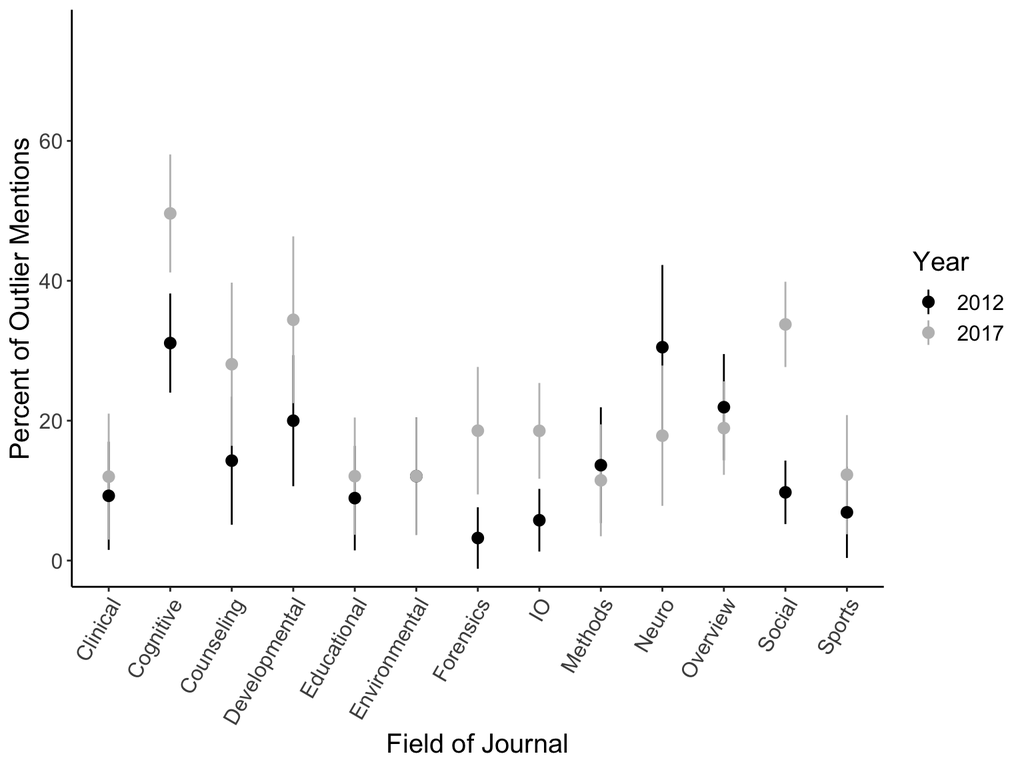

```r
dotplot
```

# Thanks for watching!

- Check out these materials: https://osf.io/afqp9/ -> Advanced Stats -> R -> Other Files